# Praca domowa 2

Hanna Szczerbińska

## Dane

Dane wykorzystane w Pracy domowej 2 opisują wycenę nieruchomości. Każda obserwacja jest pewną nieruchmością, która posiada informacje takie jak powierzchnia, liczba pokoi, liczba łazienek i wiele więcj. Opis wszystkich kolumn w pliku `README.md`.

## Zadanie 1

Jak wygląda rozkład ceny nieruchomości w poszczególnych kodach pocztowych na przestrzeni lat? Rozważamy kody pocztowe, które mają więcej niż 280 posiadłości.

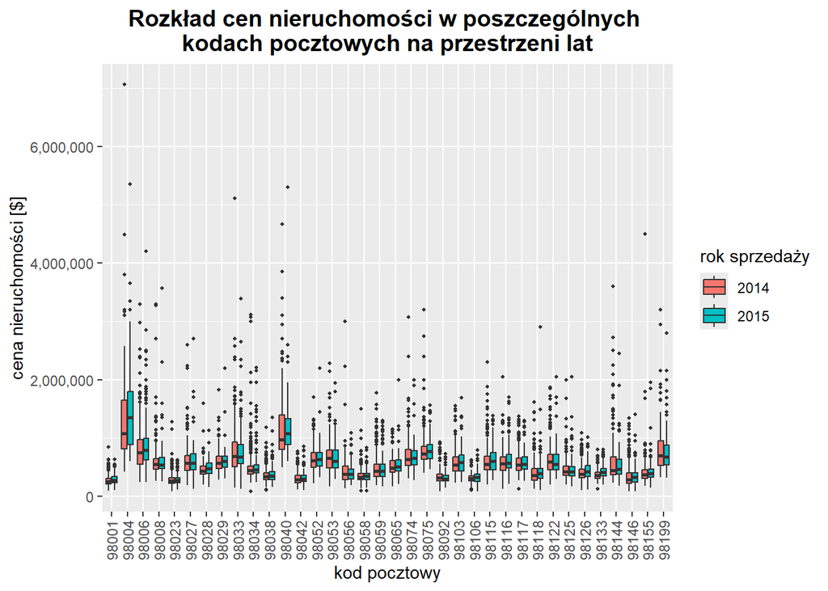

```r
df %>%
  mutate(sell_year = substr(date, 1, 4)) %>%
  select(id, sell_year, price, zipcode) %>%
  group_by(zipcode) %>%
  filter(n() > 280) %>%
  ungroup() %>%
  ggplot(aes(x = as.factor(zipcode), y = price, fill = sell_year)) +
  geom_boxplot(outlier.size = 0.75) +
  guides(x = guide_axis(angle = 90)) +
  scale_y_continuous(labels = scales::comma) +
  labs(title = "Rozkład cen nieruchomości w poszczególnych \nkodach pocztowych na przestrzeni lat",
       x = "kod pocztowy",
       y = "cena nieruchomości [$]",
       fill = "rok sprzedaży") +
  theme(plot.title = element_text(hjust = 0.5, size = 14, face = "bold"))
```

**Komentarz: mediana ceny nieruchomości w większości kodów pocztowych nieznacznie wzrosła między rokiem 2014 a 2015**

## Zadanie 2

Czy jest różnica w rozkładzie ceny nieruchomości od powierzchni mieszkalnej uwzględniając podział na nieruchomości z piwnicą i bez?

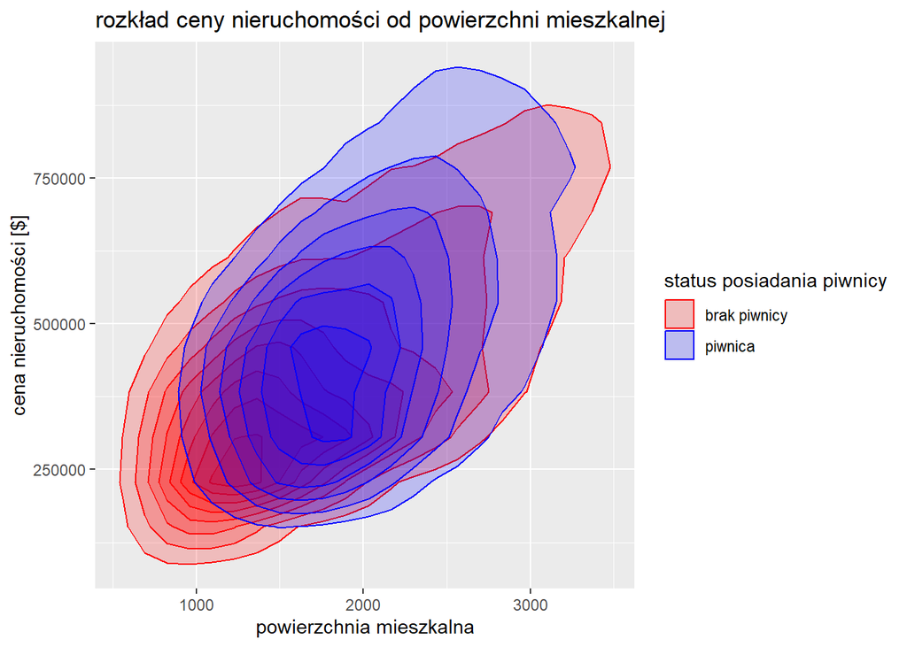

```r
df %>%
  mutate(if_basement = ifelse(sqft_basement > 0, "piwnica", "brak piwnicy")) %>%
  select(id, price, sqft_living, if_basement) %>%
  ggplot(aes(x = sqft_living, y = price, color = if_basement, fill = if_basement)) +
  stat_density_2d(aes(alpha = after_stat(level)), geom = "polygon", alpha = 0.2) +
  scale_fill_manual(values = c("brak piwnicy" = "red", "piwnica" = "blue")) +
  scale_color_manual(values = c("brak piwnicy" = "red", "piwnica" = "blue")) +
  guides(fill = guide_legend(title = "status posiadania piwnicy")) +
  labs(title = "rozkład ceny nieruchomości od powierzchni mieszkalnej",
       x = "powierzchnia mieszkalna",
       y = "cena nieruchomości [$]",
       color = "status posiadania piwnicy")
```

**Komentarz: stosunek ceny nieruchomości do powierzchni mieszkalnej jest do siebie zbliżony niezależnie od obecności piwnicy, jednak w przypadku nieruchomości bez piwnicy trochę częściej zdarzają się mniejsze i tańsze nieruchomości (w przeliczeniu na koszt stopy kwadratowej powierzchni mieszkalnej), natomiast nieruchomości z piwnicą są zazwyczaj trochę większe i droższe**

## Zadanie 3

Jaka jest zależność pomiędzy jakością wykończenia nieruchomości a liczbą pięter?

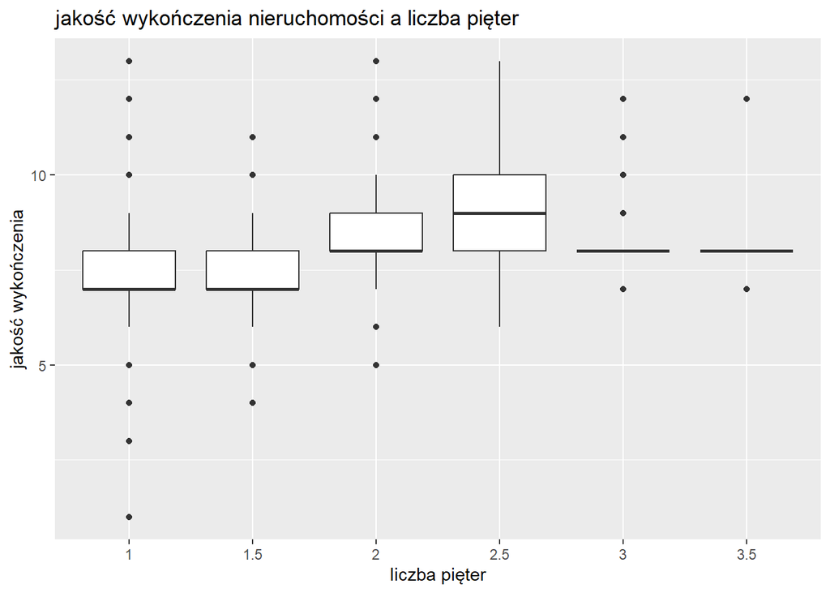

```r
df %>%
  select(id, grade, floors) %>%
  ggplot(aes(x = as.factor(floors), y = grade)) +
  geom_boxplot() +
  labs(title = "jakość wykończenia nieruchomości a liczba pięter",
       x = "liczba pięter",
       y = "jakość wykończenia")
```

**Komentarz: jakość wykończenia nieruchomości przeważnie nieznacznie rośnie wraz z liczbą pięter**

## Zadanie 4

Jaka jest zależność między powierzchnią mieszkalną nieruchomości a powierzchnią gruntu w podziale na liczbę sypialni?

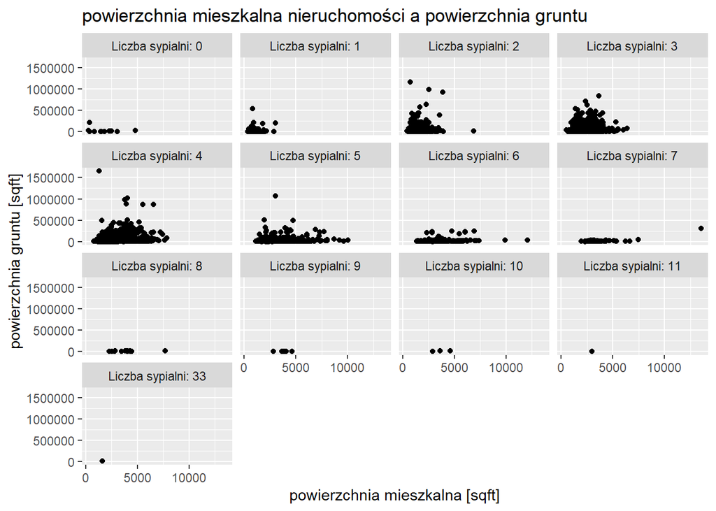

```r
# przez 'powierzchnie gruntu' rozumiem powierzchnie dzialki; gdyby to miala byc sama powierzchnia ziemi bez domu, to trzeba by bylo zrobic dodatkowe pole w ktorym odejmuje jedno od drugiego

df %>%
  select(id, sqft_living, sqft_lot, bedrooms) %>%
  ggplot(aes(x = sqft_living, y = sqft_lot)) +
  geom_point() +
  facet_wrap(~bedrooms,
             labeller = labeller(bedrooms = function(x) paste("Liczba sypialni:", x))) +
  labs(title = "powierzchnia mieszkalna nieruchomości a powierzchnia gruntu",
       x = "powierzchnia mieszkalna [sqft]",
       y = "powierzchnia gruntu [sqft]")
```

**Komentarz: rozkład powierzchni gruntu w zależności od powierzchni mieszkalnej nieruchomości jest mniej więcej jednostajny, z nieznacznie większą liczbą nieruchomości o większej powierzchni gruntu w przypadku średniej powierzchni mieszkalnej (ok. 3000-5000 sqft); dodatkowo można zauważyć, że przeważnie im większa liczba sypialni, tym większa powierzchnia mieszkalna, przy zachowaniu podobnego rozkładu powierzchni gruntu**

## Zadanie 5

Rozważmy tylko nieruchomości, które miały remont. W której dekadzie było najwięcej przeprowadzonych remontów? Czy w poszczególnych dekadach jest porównywalny procent nieruchomości dla każdej wartości miary jakości i wykończenia nieruchomości?

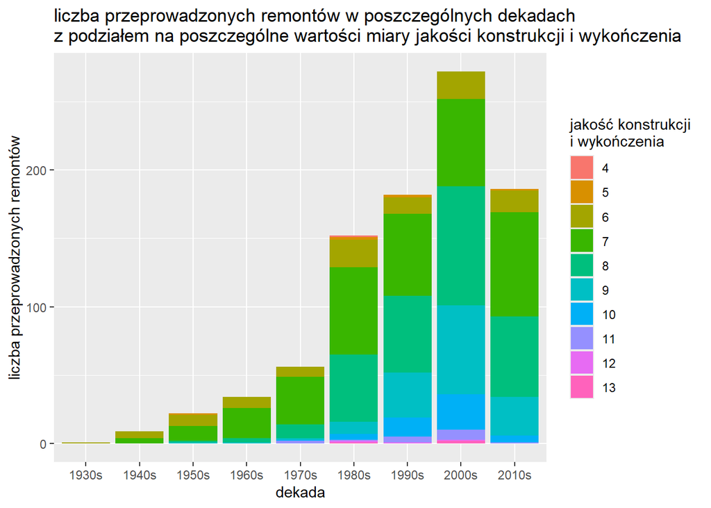

```r
df %>%
  filter(yr_renovated > 0) %>%
  mutate(decade_renovated = paste(substr(yr_renovated, 1, 3), "0s", sep="")) %>%
  group_by(decade_renovated, grade) %>%
  summarise(cnt = n()) %>%
  ungroup() %>%
  ggplot(aes(x = decade_renovated, y = cnt, fill = as.factor(grade))) +
  geom_bar(position = "stack", stat = "identity") +
  labs(title = "liczba przeprowadzonych remontów w poszczególnych dekadach \nz podziałem na poszczególne wartości miary jakości konstrukcji i wykończenia",
       x = "dekada",
       y = "liczba przeprowadzonych remontów",
       fill = "jakość konstrukcji \ni wykończenia")
```

**Komentarz: najwięcej remontów było przeprowadzonych w dekadzie 2000-2009; w późniejszych dekadach zauważalnie rośnie udział nieruchomości o wyższych wartościach miary jakości konstrukcji i wykończenia**

## Zadanie 6

Jak prezentuje się wartość minimalna, średnia i maksymalna ceny nieruchmości w podziele na rok budowy nieruchomości.

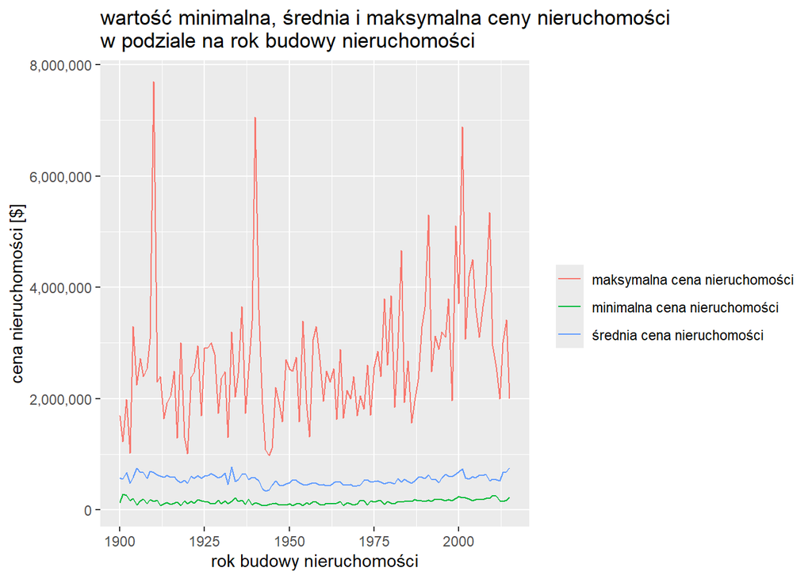

```r
df %>%
  select(id, price, yr_built) %>%
  group_by(yr_built) %>%
  summarise(avg_price = mean(price), min_price = min(price), max_price = max(price)) %>%
  ggplot(aes(x = yr_built)) +
  geom_line(aes(y = avg_price, color = "średnia cena nieruchomości")) +
  geom_line(aes(y = min_price, color = "minimalna cena nieruchomości")) +
  geom_line(aes(y = max_price, color = "maksymalna cena nieruchomości")) +
  scale_y_continuous(labels = scales::comma) +
  labs(title = "wartość minimalna, średnia i maksymalna ceny nieruchomości \nw podziale na rok budowy nieruchomości",
       x = "rok budowy nieruchomości",
       y = "cena nieruchomości [$]",
       colour = "")
```

**Komentarz: minimalna i średnia cena nieruchomości utrzymuje się od lat na podobnym poziomie; cena maksymalna zmienia się znacząco w zależności od roku**